# GWAS VI: Polygenic risk scores and LD score regression

BIOS 770

Josh Weinstock, PhD

Assistant Professor, Department of Human Genetics, Emory University

## Learning objectives

1. Define polygenic risk scores (PRS)
2. Discuss common PRS methods
3. Discuss challenges in PRS portability and interpretation
4. Discuss linkage disequilibrium score regression (LDSR)

## Genotypes → Phenotypes: Recap of GWAS

**Continuous Trait**
$$\color{darkblue}{Y}_i \sim \mathcal{N}(\color{darkgreen}{X}_i \beta, \sigma^2)$$

**Binary Trait**
$$\color{darkblue}{Y}_i \sim \text{Bernoulli}(\sigma(\color{darkgreen}{X}_i \beta))$$

- $\color{darkgreen}{X}_i$: Genotype vector (e.g., SNP counts 0/1/2)
- $\beta$: Effect sizes from GWAS
- $\sigma$: Sigmoid function for binary outcomes

## Interpretation

- $\beta$ represents **marginal effects** of genotypes on phenotypes
- PRS = $\color{darkgreen}{X}_i \hat{\beta}$ (weighted sum of risk alleles)

## Why create a PRS?

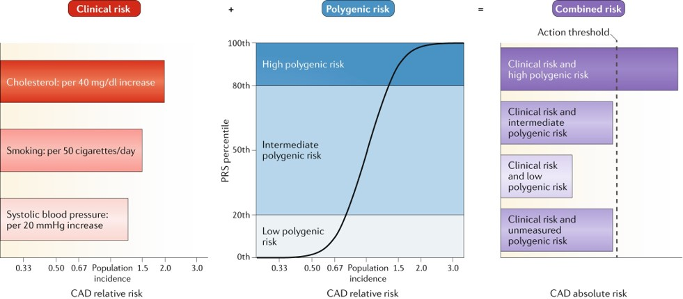

Torkamani et al., *Nature Reviews Genetics*, 2018

## Statistical methods for PRS construction

1. **Clumping and Thresholding**
   - **Clumping**: Remove SNPs in linkage disequilibrium (LD) .
   - **Thresholding**: Select SNPs with GWAS *p* < threshold.
2. **Penalized Regression**
   - LASSO/Ridge: penalize by L1 or L2 norm to either shrink coefficients or induce sparsity.
3. **Bayesian Methods (PRS-CS, LDpred, BayesR)**
   - Bayesian regression with some helpful prior.

## Creating a PRS

[figure not shown]

Wray et al., *Nature Reviews Genetics*, 2013

## Modeling linkage disequlibrium

For genotype matrix $\color{darkgreen}{X} \in \mathbb{R}^{n \times p}$ (samples $\times$ SNPs):

**Covariance**:
$$R = \text{Cov}(\color{darkgreen}{X}) = \mathbb{E}[\color{darkgreen}{X}^T \color{darkgreen}{X}] - \mathbb{E}[\color{darkgreen}{X}]^T \mathbb{E}[\color{darkgreen}{X}]$$

**Under common assumptions**:

1. Centered genotypes: $\mathbb{E}[X] = 0$
2. Unit variance: $\text{Var}(X_{i}) = 1 \forall i$

**Simplifies to Correlation Matrix**:
$$R = \text{Cor}(\color{darkgreen}{X}) = \mathbb{E}[\color{darkgreen}{X}^T \color{darkgreen}{X}]$$

## Properties of the estimator

**Good**:
$$\mathbb{E}[\hat{R}] = R \quad \text{(Unbiased)}$$

**Bad**:

- When $P \ge N$, $\hat{R}$ becomes rank-deficient:
  $$\text{rank}(\hat{R}) \leq \min(N,P) = N$$

$\hat{R}$ may also fail to be positive definite.

## GWAS Dimensionality Challenge

**Implications**:

- LD matrix estimation becomes ill-conditioned
- Matrix inversion $\hat{R}^{-1}$ unstable
- Impacts PRS methods and fine-mapping

## Recovering joint estimates from summary statistics

- GWAS estimates the marginal effects.
- These are likely to be “worse” (for prediction, loci discovery) than joint effects if the SNPs are correlated (highly common)

## Simulation: joint vs marginal coefficients

```r
N = 10000
P = 100
M = 20
h2 = 0.20
U <- qr.Q(qr(matrix(rnorm(P ^ 2), P)))
D = seq(0.01, 10, length = P)
Sigma = crossprod(U, U * D)
L = chol(Sigma)
X = matrix(rnorm(N * P), N, P) %*% L
X = scale(X) # ensure variances are 1
beta = rep(0, P)
beta_causal = sample(1:P, size = M)
beta[beta_causal] = rnorm(M, mean = 0, sd = sqrt(h2 / M))
Y = X %*% beta + rnorm(N, 0, sqrt(1.0 - h2))
```

## Joint esimates are better than marginal estimates

```r
beta_joint = coef(lm(Y ~ X + 0))
beta_gwas  = (t(X) %*% Y) / N

summary(lm(beta ~ beta_joint))[["r.squared"]]
```

```
[1] 0.8535646
```

```r
summary(lm(beta ~ beta_gwas))[["r.squared"]]
```

```
[1] 0.7479689
```

## Using sufficient statistics, convert marginal to joint

$$\begin{align}
\hat{\beta}^{\text{marg}} &= \frac{\color{darkgreen}{X}^t \color{darkblue}{Y}}{N} \\
(\color{darkgreen}{X}^t \color{darkgreen}{X})^{-1} \hat{\beta}^{\text{marg}} &= (\color{darkgreen}{X}^t \color{darkgreen}{X})^{-1}\frac{\color{darkgreen}{X}^t \color{darkblue}{Y}}{N} \\
(N\hat{R})^{-1} \hat{\beta}^{\text{marg}} &= \frac{(\color{darkgreen}{X}^t \color{darkgreen}{X})^{-1} * \color{darkgreen}{X}^t \color{darkblue}{Y}}{N} \\
\hat{R}^{-1} \hat{\beta}^{\text{marg}} &= \hat{\beta}^{joint}
\end{align}$$

Asymptotically:
$$\hat{\beta}^{\text{marg}} \sim \mathcal{N}\left(\hat{R}\beta, \frac{\sigma^2}{N}\hat{R} \right)$$

*What we get from GWAS ($\hat{\beta}^{\text{marg}}$) are the true coefficients ($\beta$) “rotated” by LD ($R$) + noise*

## GWAS summary statistics

1. Often, we don’t have access to individual level data
2. But we can pair sufficient statistics from GWAS with LD estimates from a population reference panel
3. This information is sufficient to approximate an individual level likelihood without requiring individual genotypes from the GWAS

## In summary so far

1. GWAS estimates marginal effects
2. We always want to convert these to joint estimates for prediction purposes
3. We can actually do this without needing to re-analyze the original individual level GWAS data

## Methods for computing PRS

## Clumping and thresholding

1. Perform GWAS
2. “Clump” correlated variants together / LD-prune
3. Simply take all betas where the pvalue is less than some threshold
4. Note, no conversion from marginal to joint here

## LDPred: Bayesian linear regression

### Prior on the SNP effects: spike and slab

$$\beta_i \stackrel{\text{iid}}{\sim} \begin{cases}
\mathcal{N}\left(0, \dfrac{h_g^2}{M_p}\right) & \text{with probability } p \\
0 & \text{with probability } (1-p)
\end{cases}$$

### Posterior expectation without LD

$$\mathbb{E}\left(\beta_i \mid \hat{\beta}_i^{marg} \right) = \left(\dfrac{h_g^2}{h_g^2 + \dfrac{M_p}{N}}\right) \bar{p}_i \hat{\beta}^{marg}_i$$

## Estimates in the presence of LD

$$\mathbb{E}\left(\beta_i \mid \hat{\beta}_i^{marg}, \mathbf{\hat{R}} \right) = \left(\mathbf{\hat{R}} + I \dfrac{M}{Nh_g^2}\right)^{-1} \hat{\beta}^{marg}_i$$

## Simulation

```r
beta_joint = coef(lm(Y ~ X + 0))
beta_gwas  = (t(X) %*% Y) / N
beta_ld_pred_inf = solve(cor(X) + diag(P) * (M / N * h2), beta_gwas)

summary(lm(beta ~ beta_joint))[["r.squared"]]
```

```
[1] 0.8535646
```

```r
summary(lm(beta ~ beta_gwas))[["r.squared"]]
```

```
[1] 0.7479689
```

```r
summary(lm(beta ~ beta_ld_pred_inf))[["r.squared"]]
```

```
[1] 0.8629468
```

## LDPred induces shrinkage towards origin

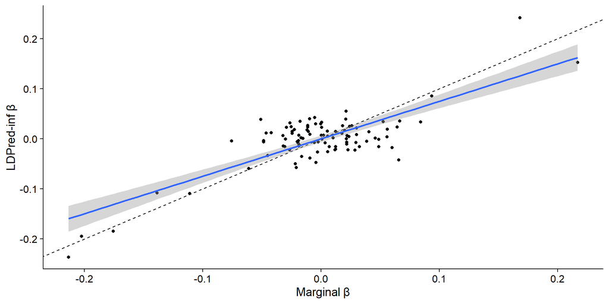

## Connections to ridge regression

$$\hat{\beta}^{ridge} = (\color{darkgreen}{X}^t \color{darkgreen}{X} + \lambda I)^{-1}\color{darkgreen}{X}^t \color{darkblue}{Y}$$

$$\mathbb{E}\left(\beta_i \mid \hat{\beta}_i^{marg}, \mathbf{\hat{R}} \right) = \left(\mathbf{\hat{R}} + I \dfrac{M}{Nh_g^2}\right)^{-1} \hat{\beta}^{marg}_i$$

$$\lambda \approx \dfrac{M}{Nh_g^2}$$

## Lasso derived PRS

Minimize:
$$(\color{darkblue}{Y} - \color{darkgreen}{X}\beta)^t(\color{darkblue}{Y} - \color{darkgreen}{X}\beta) + \lambda||\beta||_1$$

This can be approximated with summary statistics:
$$\color{darkblue}{y}^t\color{darkblue}{y} + \beta^{t}\hat{R}\beta - 2\beta^{t}N\hat{\beta}^{marg} + \lambda||\beta||_1$$

**Mak et al., *Genetic Epidemiology*, 2017**

## Simulation with glmnet as a proxy

```r
library(glmnet)

lasso = glmnet(X, Y, alpha = 1.0)
lasso_estimates = as.vector(coef(lasso, s = 0.01))[2:(P + 1)]

summary(lm(beta ~ beta_joint))[["r.squared"]]
```

```
[1] 0.8535646
```

```r
summary(lm(beta ~ beta_gwas))[["r.squared"]]
```

```
[1] 0.7479689
```

```r
summary(lm(beta ~ beta_ld_pred_inf))[["r.squared"]]
```

```
[1] 0.8629468
```

```r
summary(lm(beta ~ lasso_estimates))[["r.squared"]]
```

```
[1] 0.9905764
```

## PRSCS: Bayesian linear regression with continuous shrinkage prior

$$\beta_i \sim \mathcal{N}\left(0, \frac{\sigma^2}{N} \lambda_i \tau \right) \\
\lambda_i \sim Gamma(a, \delta_i) \\
\delta_i \sim Gamma(b, 1) \\
\sqrt{\tau} \sim \mathcal{C}^{+}(0, 1)$$

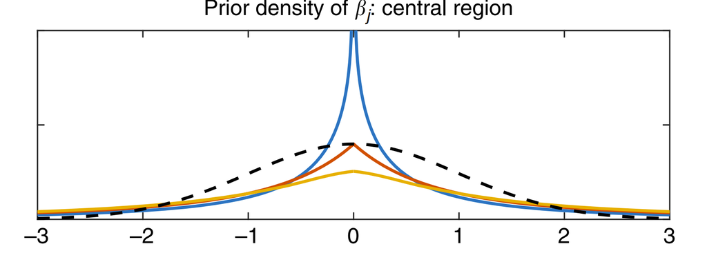

Ge et al., 2019, *Nature Communications*

## PRSCS intuition

$$\mathbb{E}\left(\beta_i \mid \hat{\beta}_i^{marg}, \mathbf{\hat{R}} \right) = \left(\mathbf{\hat{R}} + \mathbf{T}^{-1} \right)^{-1} \hat{\beta}^{marg}_i$$

### No LD case (simplification)

$$\mathbb{E}\left(\beta_i \mid \hat{\beta}_i^{marg} \right) = \left(1 - \omega_i \right) \hat{\beta}^{marg}_i \\
\omega_i = \frac{1}{(1 + \lambda_i \tau)}$$

## $\omega_i$ prior

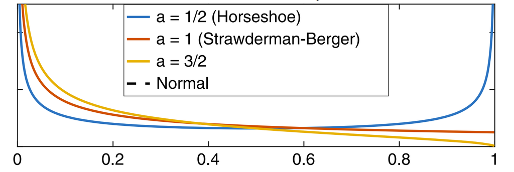

## SBayesR: Bayesian linear regression with a mixture distribution prior

$$\beta_j \mid \pi, \sigma_{\beta}^2 =
\begin{cases}
0 & \text{with probability } \pi_1, \\
\sim N(0, \gamma_2 \sigma_{\beta}^2) & \text{with probability } \pi_2, \\
\vdots & \vdots \\
\sim N(0, \gamma_C \sigma_{\beta}^2) & \text{with probability } 1 - \sum_{c=1}^{C-1} \pi_c,
\end{cases}$$

**Lloyd-Jones^, Zeng^ et al., *Nature Communications*, 2019**

## SBayesRC: SBayesR, but prior is informed by functional annotations

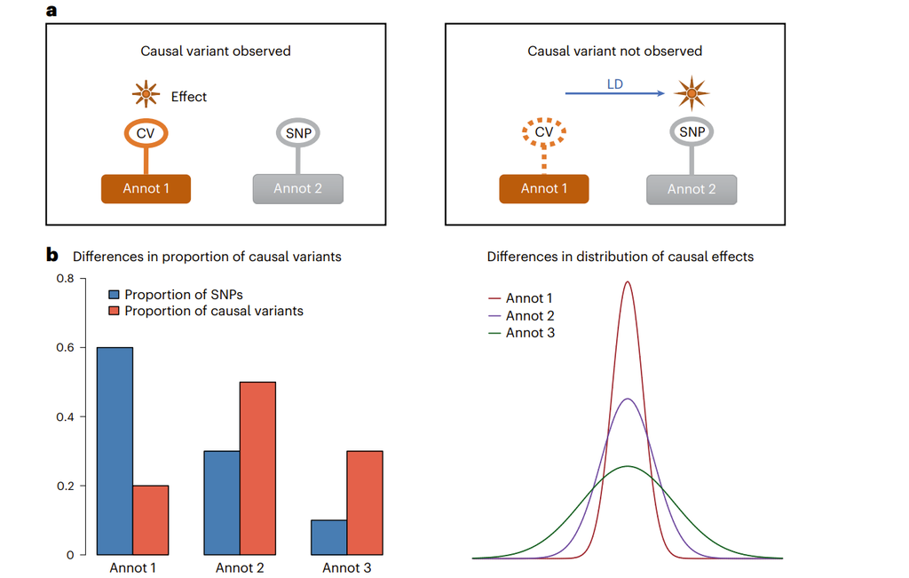

Figure 1, Zheng et al., 2024, *Nature Genetics*

## Contribution of annotations to mixture probabilities

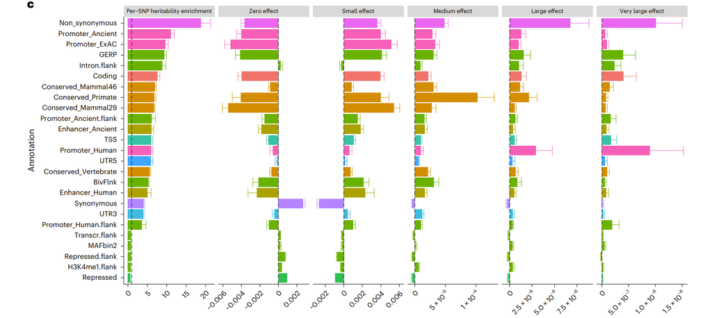

## Non-parametric Bayesian PRS with dirichlet process regression

$$\sigma^2_\beta \sim \mathbf{G} \\
\mathbf{G} \sim DP(\mathbf{H}, \lambda)$$

- $\mathbf{H}$ is a “base distribution”
- $\lambda$ is a concentration parameter

**Zeng et al., *Nature Communications*, 2017**

## “Stick-breaking” interpretation

$$\beta_{i} \sim \sum_{k=1}^{\infty} \pi_{k} N\left(0, \sigma_{k}^{2}\right) \\
\pi_{k} = \nu_{k} \prod_{l=1}^{k-1} (1 - \nu_{l}), \quad \nu_{k} \sim \mathrm{Beta}\left(1, \lambda\right)$$

## Review

1. PRS methods generally select and/or shink coefficients
2. It helps to use LD to convert from marginal to joint estimates
3. Several different Bayesian priors have shown to be useful in different ways
4. Bayesian methods offer a framework to include external functional annotations

## PRS limitations: do PRS transfer across ancestries?

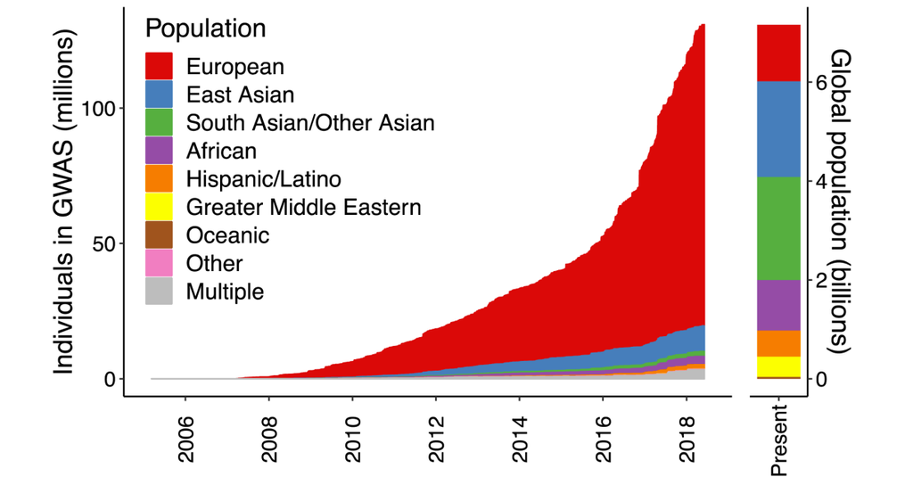

Figure 1., Martin et al., *Nature Genetics*, 2019

## PRS performance decays in test-set different in ancestry from GWAS cohort

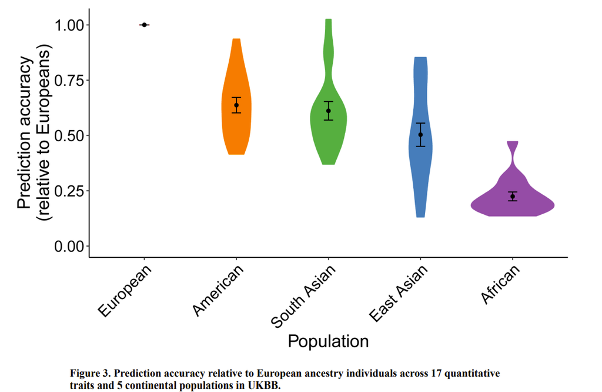

Figure 3., Martin et al., *Nature Genetics*, 2019

## Portability is inversely proportional to PCA distance

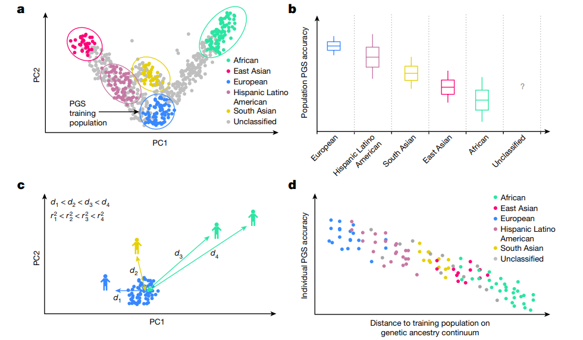

Figure 1, Ding et al., *Nature*, 2023

## Effect apparent even within discrete ancestry clusters

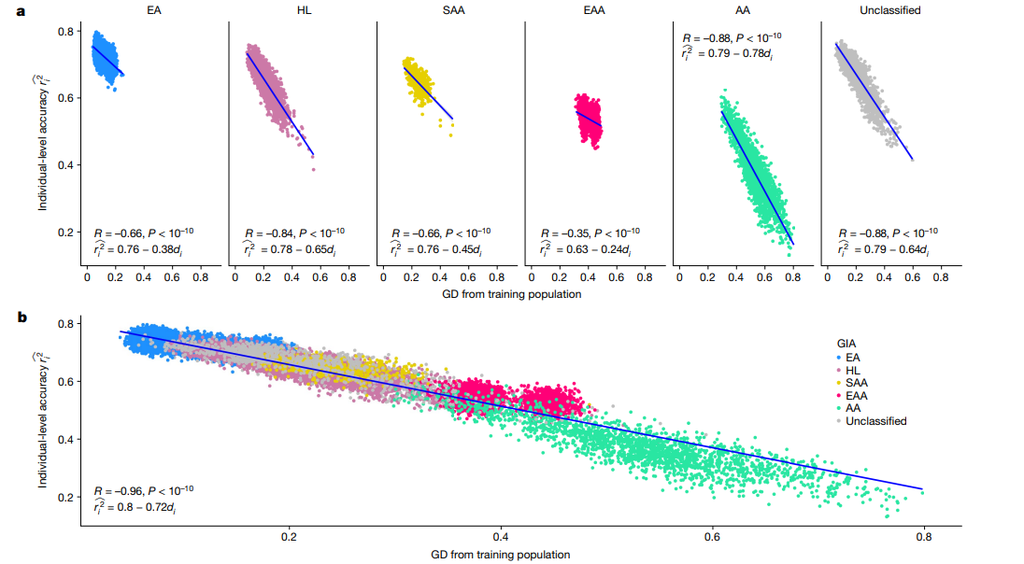

Figure 3, Ding et al., *Nature*, 2023

## Why does this happen?

1. Causal variants vary in allele frequency across ancestries
2. Causal variants vary across ancestries
3. LD differences across ancestries

## Allele frequency and LD variation

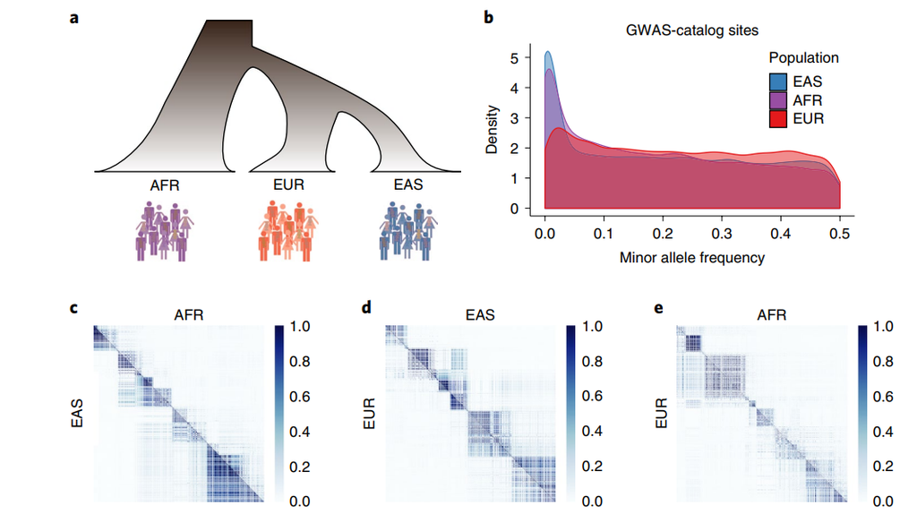

Martin et al., Figure 3, *Nature Genetics*, 2019

## Multi-ancestry PRS extensions

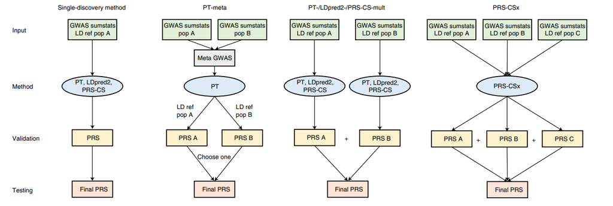

Ruan et al., Figure 1, *Nature Genetics*, 2022

## Linkage disequilibrium regression

*How can we characterize the mechanisms that manifest in a particular distribution of GWAS test statistics? Why are test statistics frequently inflated?*

1. The trait many have many causal loci (degree of polygenicity)
2. Inflation or deflation may occur as a consequence of population stratification, invalidation of homoscedascity, poor asymptotic approximations to tail probabilities used to compute pvalues

## LD Scores and $\chi^2$-Statistics

- Effect size estimate: $\hat{\beta}_j^{marg} = \color{darkgreen}{X}_j^\top y/N$
- $\chi_j^2 = N\left(\hat{\beta}^{marg}_j\right)^2$
- Define the **LD Score** of variant $j$ as: $\ell_j := \sum_{k=1}^M r_{jk}^2$

**Proposition: Under this model, the expected $\chi^2$-statistic is**:
$$\mathbb{E}[\chi_j^2] \approx \frac{N h_g^2}{M}\ell_j + 1$$

**Bulk-Sullivan et al., *Nature Genetics*, 2015**

## Proof step 1: law of total variance

Decompose $\mathrm{Var}[\hat{\beta}_j]$:
$$\mathrm{Var}[\hat{\beta}_j] = \underbrace{\mathbb{E}[\mathrm{Var}[\hat{\beta}_j \mid \color{darkgreen}{X}]]}_{\text{Main term}} + \underbrace{\mathrm{Var}[\mathbb{E}[\hat{\beta}_j \mid \color{darkgreen}{X}]]}_{\text{Vanishes}}$$
The second term vanishes because $\mathbb{E}[\hat{\beta}_j \mid \color{darkgreen}{X}] = 0$.

## Step 2: conditional variance

Given $X$, the variance becomes:
$$\mathrm{Var}[\hat{\beta}_j \mid \color{darkgreen}{X}] = \frac{1}{N^2} \color{darkgreen}{X}_j^\top \mathrm{Var}[\color{darkblue}{y} \mid \color{darkgreen}{X}] \color{darkgreen}{X}_j$$
Substitute $y = X= \color{darkgreen}{X}\beta + \epsilon$, and note $Var(\beta) = I\frac{h_g^2}{M}$:
$$= \frac{1}{N^2} \left(\frac{h_g^2}{M} \color{darkgreen}{X}_j^\top \color{darkgreen}{X} \color{darkgreen}{X}^\top \color{darkgreen}{X}_j + N(1-h_g^2)\right)$$

## Step 3: Sample LD scores

Rewrite the key quadratic form:
$$\frac{1}{N^2} \color{darkgreen}{X}_j^\top \color{darkgreen}{X} \color{darkgreen}{X}^\top \color{darkgreen}{X}_j = \sum_{k=1}^M \tilde{r}_{jk}^2$$
where $\tilde{r}_{jk} := \frac{1}{N}\sum_{i=1}^N \color{darkgreen}{X}_{ij} \color{darkgreen}{X}_{ik}$ (sample LD).

## Step 4: Expectation

Using the $\delta$-method approximation:
$$\mathbb{E}[\tilde{r}_{jk}^2] \approx r_{jk}^2 + \frac{1 - r_{jk}^2}{N}$$
Summing over $k$ gives:
$$\mathbb{E}\left[\sum_{k=1}^M \tilde{r}_{jk}^2\right] \approx \ell_j + \frac{M - \ell_j}{N}$$

## Step 5: Final steps

Combine all terms:
$$\mathbb{E}[\chi_j^2] \approx \frac{N h_g^2}{M} \left(\ell_j + \frac{M - \ell_j}{N}\right) + (1 - h_g^2)$$
Simplify for large $N$:
$$\mathbb{E}[\chi_j^2] \approx \frac{N h_g^2}{M}\ell_j + 1$$

## Extension to SNP annotations

$$\mathbb{E}[\chi_{j}^{2}] = N c \sum_{C} \tau_{C} \ell(j, C) + N a + 1$$

**Finucane et al., *Nature Genetics*, 2015**

## Contribution of annotations to SNP heritability across traits

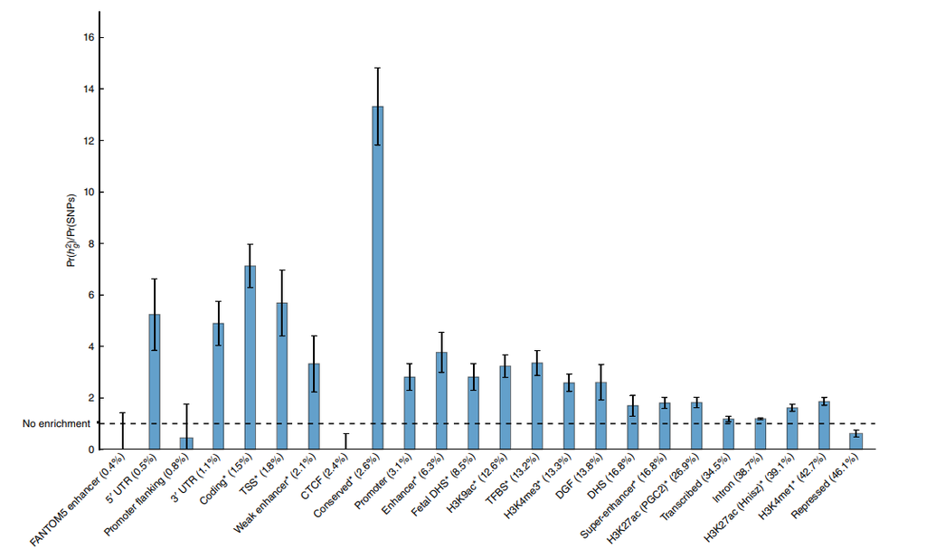

Figure 3, Finucane et al.

## Contribution of cell types to trait heritability

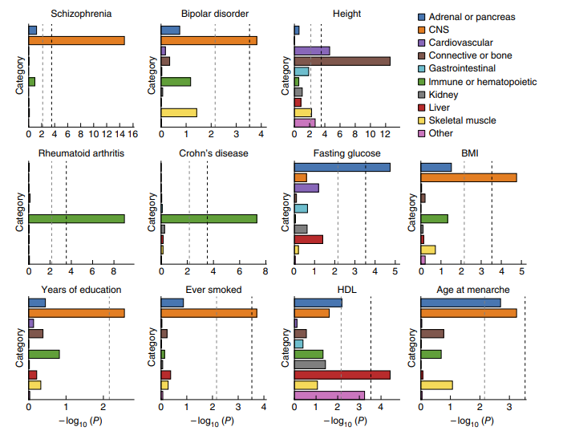

Figure 6, Finucance et al.

## Cross-trait LD score regression

*Can we use summary statistics to infer the genetic correlation between traits?*
$$\mathbb{E}[z_{1j} z_{2j}] = \frac{\sqrt{N_1 N_2} \, \rho_g}{M} \, t_j + \frac{\rho N_s}{\sqrt{N_1 N_2}}$$

**Bulik-Sullivan & Finucance et al., *Nature Genetics*, 2015**

## Cross-trait LD score

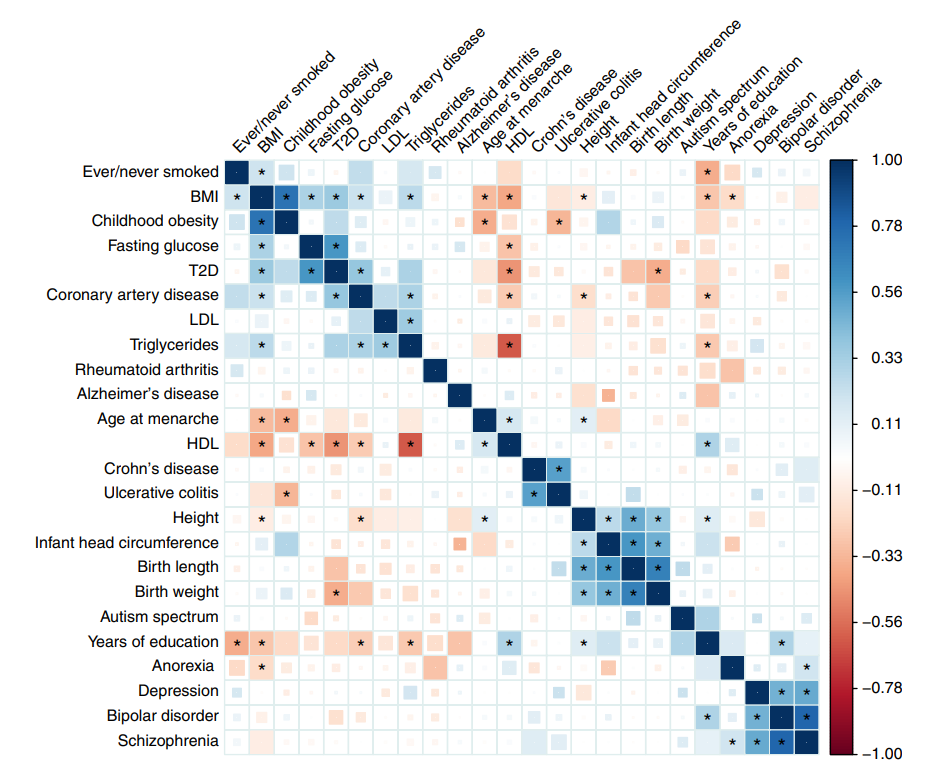

Figure 2, Bulik-Sullivan et al.

## Effects of assorative mating on cross-trait LD score regression

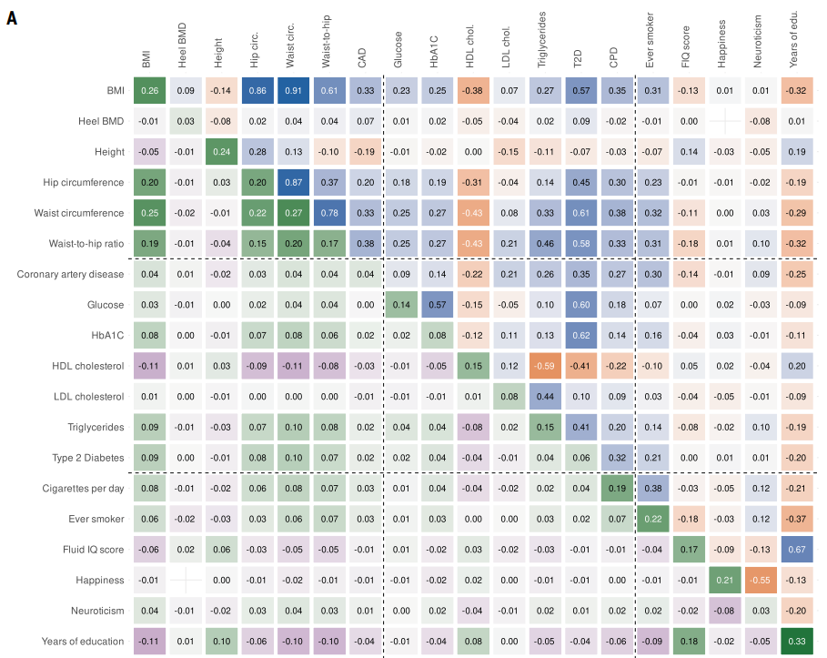

Figure 1., Border et al., *Science*, 2022

## Forward simulations are consistent with empirical observations

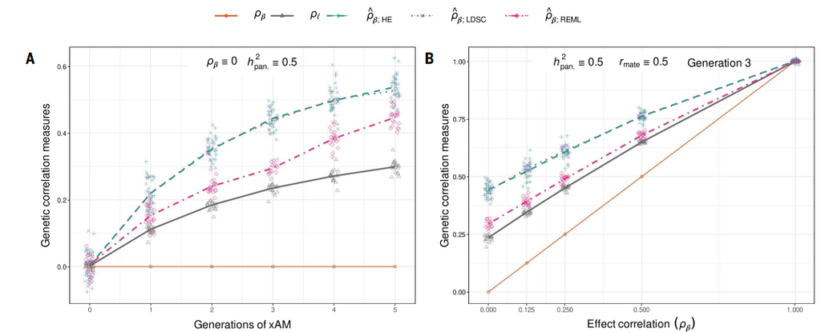

Figure 2., Border et al., *Science*, 2022

## Summary

1. PRS are estimators of genetic risk/liability/propensity for a particular phenotype
2. Numerous PRS methods have emerged, all generally bespoke versions of Bayesian or penalized regression
3. LD score regression is a powerful tool for partitioning heritability within and across phenotypes